# IMDB_Movie_Analysis

**Kirti Anand: GH1023762**

This is my final Assessment .html file which will be submitted on canvas.

The Data I have used is Internet based Movie Database to analyse different recommendations based on the features labels. The dataset includes reviews and ratings according to the different genres.

Kaggle. 2021. imdb-top-250-movies. [ONLINE] Available at: Kaggle [Accessed 23 March 2023].

I have imported the below libraries :

1. Pandas for Data.
2. Seaborn for Visualization
3. Matplotlib for Visualization
4. Warnings to handle warnings
5. plotly for graphs

[figure not shown]

**Introduction to the dataset -**

IMDB is the online database of information

IMDB is a internet Database largest databases for TV and movies.

Features of the data are movie title, ratings, tagline, budget, box office, certificate, run time, director, name, votes, casts, writers and year of release.

- Genres has categorical data which includes dram, action, comedy, adventure, horror, biography, science and romance styles.
- Ratings are provided from 1 to 10 scale
- Certificates are the rating provided by the certification board

```python
import pandas as pd
import numpy as np
import matplotlib.pyplot as plt
import warnings
warnings.filterwarnings("ignore")
import plotly.express as px
%matplotlib inline
import plotly.graph_objects as go
import seaborn as sns
```

# Exploratory Data Analysis

```python
movies_data = pd.read_csv("Movies.csv")
```

```python
movies_data.head(1)
```

|  | rank | name | year | rating | genre | certificate | run_time | tagline | budget | box_office | casts | directors | writers |
| --- | --- | --- | --- | --- | --- | --- | --- | --- | --- | --- | --- | --- | --- |
| 0 | 1 | The Shawshank Redemption | 1994 | 9 | Drama | R | 2h 22m | Fear can hold you prisoner. Hope can set you f... | 25000000 | 28884504 | Tim Robbins,Morgan Freeman,Bob Gunton,William ... | Frank Darabont | Stephen King,Frank Darabont |

```python
movies_data.tail(1)
```

|  | rank | name | year | rating | genre | certificate | run_time | tagline | budget | box_office | casts | directors | writers |
| --- | --- | --- | --- | --- | --- | --- | --- | --- | --- | --- | --- | --- | --- |
| 249 | 250 | Dances with Wolves | 1990 | 8 | Adventure,Drama,Western | PG-13 | 3h 1m | Inside everyone is a frontier waiting to be di... | 22000000 | 424208848 | Kevin Costner,Mary McDonnell,Graham Greene,Rod... | Kevin Costner | Michael Blake |

```python
movies_data.info()
```

[output not shown]

- Checking the shape of the dataset and all the columns of dataset by using shape method.

```python
print('-'*5, "Shapes of all columns from Movie Data :" ,"{}".format(movies_data.shape), '-'*5, "\n")

print(' 1. Rank : ', movies_data.shape)
print(' 2. Name : ', movies_data.shape)
print(' 3. Year : ', movies_data.shape)
print(' 4. Rating : ', movies_data.shape)
print(' 5. Genre: ', movies_data.shape)
print(' 6. Certificate : ', movies_data.shape)
print(' 7. Run-Time : ', movies_data.shape)
print(' 5. Tagline : ', movies_data.shape)
print(' 6. Budget : ', movies_data.shape)
print(' 7. Box Office : ', movies_data.shape)
print(' 5. Casts : ', movies_data.shape)
print(' 6. Directors : ', movies_data.shape)
print(' 7. Writers : ', movies_data.shape)
```

```
----- Shapes of all columns from Movie Data : (250, 13) -----

 1. Rank :  (250, 13)
 2. Name :  (250, 13)
 3. Year :  (250, 13)
 4. Rating :  (250, 13)
 5. Genre:  (250, 13)
 6. Certificate :  (250, 13)
 7. Run-Time :  (250, 13)
 5. Tagline :  (250, 13)
 6. Budget :  (250, 13)
 7. Box Office :  (250, 13)
 5. Casts :  (250, 13)
 6. Directors :  (250, 13)
 7. Writers :  (250, 13)
```

```python
movies_data.describe()
```

|  | rank | year | rating |
| --- | --- | --- | --- |
| count | 250.000000 | 250.000000 | 250.000000 |
| mean | 125.500000 | 1986.360000 | 8.307200 |
| std | 72.312977 | 25.125356 | 0.229081 |
| min | 1.000000 | 1921.000000 | 8.000000 |
| 25% | 63.250000 | 1966.250000 | 8.100000 |
| 50% | 125.500000 | 1994.000000 | 8.200000 |
| 75% | 187.750000 | 2006.000000 | 8.400000 |
| max | 250.000000 | 2022.000000 | 9.300000 |

- Converting data type of feature 'rating' into integer

```python
movies_data['rating'] = movies_data['rating'].astype('int')
```

```python
movies_data.isnull().sum()
```

```
rank           0
name           0
year           0
rating         0
genre          0
certificate    0
run_time       0
tagline        0
budget         0
box_office     0
casts          0
directors      0
writers        0
dtype: int64
```

- Displaying all numerical columns

```python
movies_data.select_dtypes(include='number')
```

|  | rank | year | rating |
| --- | --- | --- | --- |
| 0 | 1 | 1994 | 9 |
| 1 | 2 | 1972 | 9 |
| 2 | 3 | 2008 | 9 |
| 3 | 4 | 1974 | 9 |
| 4 | 5 | 1957 | 9 |
| ... | ... | ... | ... |
| 245 | 246 | 2011 | 8 |
| 246 | 247 | 1975 | 8 |
| 247 | 248 | 1992 | 8 |
| 248 | 249 | 1982 | 8 |
| 249 | 250 | 1990 | 8 |

250 rows × 3 columns

- There are 250 records and 13 columns in the dataset
- Genres column has categories or types of movies based on their type of content
- Further I will be using the whole dataset for data processing and data visualization.

# Data Visualization

**Checking outliers for all the numerical columns from the dataset which is required for further analysis**

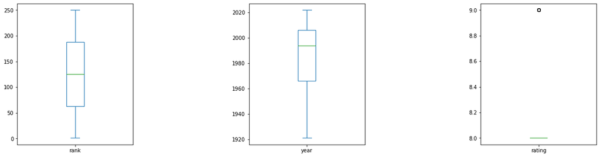

```python
movies_data.plot(
    kind='box',
    subplots=True,
    sharey=False,
    figsize=(20, 5)
)
plt.subplots_adjust(wspace=1)
plt.show()
```

```python
filtering = (movies_data['rating'] > 8)
filtering.value_counts ()
```

```
False    243
True       7
Name: rating, dtype: int64
```

```python
for n in np.where(movies_data['rating'] > 10000):
  movies_data.drop(n)
```

**Checking the correlations between columns**

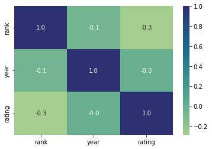

```python
sns.heatmap(movies_data.corr(),cmap = "crest", annot = True, fmt = ".1f")
```

[output not shown]

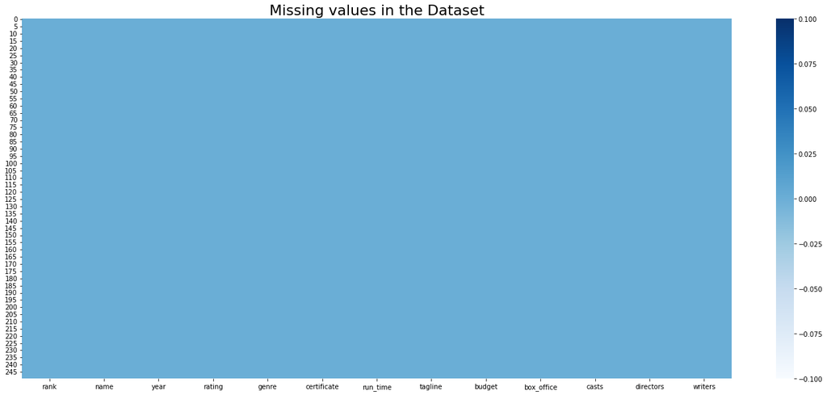

```python
print("Shape of Movie Data :" ,"{}".format(movies_data.shape), "\n")
set_cols = movies_data.columns
plt.figure(figsize = (24, 10))
sns.heatmap(movies_data[set_cols].isnull(),
            cmap = "Blues")
plt.title("Missing values in the Dataset", size = 22);
```

No missing values observed from the above heatmap representations

- Here I am dropping the duplicate records if any to ensure to keep one of then which is the first entry.

```python
movies_data.drop_duplicates(keep='first',inplace=True)
```

Displaying the genres name to analyse informative data

```python
movies_data.iloc[20].genre
```

```
'Drama,Family,Fantasy'
```

**Creating and Ploting Word Cloud**

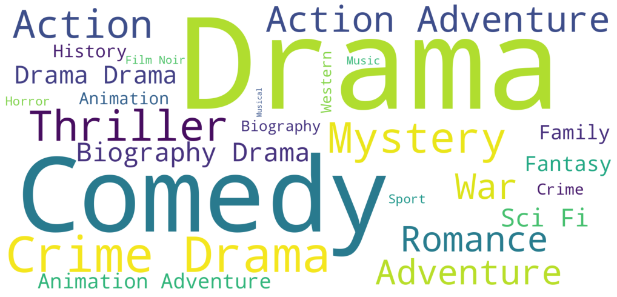

```python
from wordcloud import STOPWORDS as stopwords_wc
from wordcloud import ImageColorGenerator, WordCloud

all_genre = " ".join(spoken for spoken in movies_data["genre"])
stopwords_wc = set(stopwords_wc)

wording = WordCloud(stopwords = stopwords_wc,
                      max_font_size = 400,
                      random_state = 52, max_words = 1400,
                      width = 1900, height = 900,
                      background_color = 'white')
wording.generate(all_genre)

plt.figure(figsize = (18, 9))
plt.axis("off")
plt.imshow(wording)
plt.show();
```

According to the above Word Cloud representation, all the genres are displayed in a better visualization of text data into pattern

**Displaying Count Plot through sns for 'rating' feature**

[figure not shown]

```python
sns.countplot (movies_data['rating'])
```

**Clearing Null Values in the below features :**

- Name
- Tagline
- Directors
- Casts
- Genre

```python
null_value = movies_data.fillna('')
features = ['name', 'directors', 'casts', 'genre', 'tagline']
def null_fill(x):
    return x['name']+' '+ x['directors']+' '+ x['casts'] +' '+x['genre']+' '+x['tagline']
```

# **1. Which Genre movies has the highest movie ratings?**

```python
top_rating = movies_data.groupby('genre').mean().sort_values('rating',ascending=False).head(5)
top_rating = top_rating[['rating']].round(2)
top_rating.reset_index(inplace=True)
top_rating
data_figure = px.violin(movies_data, x='genre', y='rating', color='genre', title='Highest Movie Ratings according to Genre')
data_figure.show()
```

[interactive chart not shown]

**Summary :**

From the above violin plot, it is observed that Drama, Crime, Action, Biography and History are the highest 5 Genres populated from the dataset.

# **2. What are the top 10 movies recommendation according to Ratings?**

```python
top_genre = movies_data.sort_values(by='rating', ascending=False).head(10)
```

```python
top_ratings = movies_data.nlargest(10, 'rating')
fig = go.Figure(data=[go.Bar(x = top_ratings['name'], y = top_ratings['rating'], marker = {'color': '#dba506'})])
fig.update_layout(title = 'Top 10 Movies recommendation considering Rating')
fig.show()
```

[interactive chart not shown]

**Summary :**

From the above Bar plot, 'The Shawshank Redemption' is the most rated movie which is populated from the dataset.

# **3. Which are the most common genre movies with the highest ratings?**

```python
top_genre = movies_data.nlargest(10,'rating')
data_figure = go.Figure(data = [go.Bar(x = top_genre['genre'], y = top_genre['rating'], marker = {'color': '#dba506'})])
data_figure.update_layout(title='Common Genre recommendations', )
data_figure.show()
```

[interactive chart not shown]

**Summary :**

From the above Bar plot it can be said that Crime and Drama genre has the highest ratings from the other genres.

# **4. Which director has the most movies on the list?**

```python
gen_year = movies_data.pivot_table(index='directors', columns='year', values='rating', aggfunc='mean')
figure_data = px.imshow(gen_year, color_continuous_scale = 'Reds',
                 title = ' Highest Movie count directed by director')
figure_data.update_layout(xaxis_title = '-Year-', yaxis_title = '-Directors-')
figure_data.show()
```

[interactive chart not shown]

# **5. Which certified movies has the highest rating?**

```python
figure_data = px.box(movies_data, x='certificate', y='rating', color='certificate',
             title='Movies Top Ratings by Certificate')
figure_data.update_layout(xaxis_title='Certificate', yaxis_title='Rating')
figure_data.show()
```

[interactive chart not shown]

**Summary :**

According to the above box plot it is observed that the 'R' rated movies has the high ratings!

**Conclusion :**

After exploring and analysing the features of the data set those have contributed to a movie's success and popularity. We have gained the different insights from the data and tried to simplify data with some popular questions searched over internet regarding movies such as top 10 movies to watch in 2021, top director's movies and most watched gernes.

**Coverting File to HTML**

```python
!jupyter nbconvert --to html IMDB_Movie_Analysis.ipynb
```

```
[NbConvertApp] Converting notebook IMDB_Movie_Analysis.ipynb to html
[NbConvertApp] Writing 1957218 bytes to IMDB_Movie_Analysis.html
```

[figure not shown]